# WORKFLOW_PARTE_1

**DATA SCIENCE PROJECT**

**WORKFLOW PARTE 1 DO PROJETO**

NOME COMPLETO: Luiz Felipe Pereira Figueiredo

LINK PARA SEU PRÓPRIO COLAB: [Aqui](https://drive.google.com/file/d/1Im9HGz79BNSDO7xBj6atqvEZdaFspF_h/view?usp=sharing)

LINK PARA SEU PRÓPRIO GITHUB: [Aqui](https://github.com/Sparkvni/projeto_integrador_final)

LINK PARA SEU VÍDEO NO YOUTUBE: [Aqui](https://www.youtube.com/watch?v=FvThrWo7jNw)

[figure not shown]

[figure not shown]

# **Cenário Fictício**:

Prezados(as) alunos(as),

É com entusiasmo que apresento a proposta do **Projeto de Conclusão de Curso (TCC)** para os estudantes do curso de Ciência de Dados da Universidade Vila Velha: o UWine – Clube de Vinhos da UVV.

A proposta do projeto consiste na análise de um Clube de Vinhos universitário fictício, com base em dados simulados, que será totalmente orientado por técnicas e práticas de Ciência de Dados.

Sendo assim, você foi designado como **Consultor em Ciência de Dados** ( **Data Science Consultant** ) para fazer uma análise completa dos dados dos clientes a partir de um conjunto de dados (Amostra) com mais de 1 milhão de notas fiscais (~ 350 Megabytes). Além disso, há uma entrada diária de aproximadamente umas 5000 novas notas fiscais no sistema.

O objetivo é permitir que cada consultor(a) percorra foco analíticos diferentes dentro do mesmo ecossistema de dados, aplicando modelos de machine learning supervisionado ou não supervisionado, análise preditiva, dashboards interativos, entre outros.

Para garantir organização, profundidade técnica e coerência metodológica no desenvolvimento do **Projeto UWine**, adotaremos um workflow composto por cinco etapas principais, alinhadas às boas práticas da Ciência de Dados. Cada etapa representa um marco do processo analítico, permitindo que cada analista avance de forma estruturada do entendimento inicial dos dados até a entrega final dos insights.

# BIBLIOTECAS E FUNÇÕES E CÓDIGOS

```python
import pandas as pd
import numpy as np
import matplotlib.pyplot as plt
import seaborn as sns
import scipy.stats as stats
from scipy.stats import bootstrap

# Example of the Normality Test
from scipy.stats import skew, kurtosis, norm
from scipy.stats import anderson
from scipy.stats import shapiro
from scipy.stats import normaltest

# Example of the Correlation Tests
from scipy.stats import pearsonr
from scipy.stats import spearmanr
from scipy.stats import kendalltau
from scipy.stats import chi2_contingency

# Parametric Statistical Hypothesis Tests

# Example of the Student's t-test
from scipy.stats import ttest_ind
# Example of the Paired Student's t-test
from scipy.stats import ttest_rel
# Example of the Analysis of Variance Test: ANOVA
from scipy.stats import f_oneway

# Nonparametric Statistical Hypothesis Tests

# Example of the Mann-Whitney U Test
from scipy.stats import mannwhitneyu
# Example of the Wilcoxon Signed-Rank Test
from scipy.stats import wilcoxon
# Example of the Kruskal-Wallis H Test
from scipy.stats import kruskal
# Example of the Friedman Test
from scipy.stats import friedmanchisquare
pd.set_option('display.max_columns', None)
sns.set_theme(style="whitegrid")
```

```python
# load do seu TABLE ? aqui: Numero ???
df = pd.read_csv('table6.csv')
df = df.drop(columns=['index', 'Unnamed: 0'], axis=0)
# CORREÇÃO DO ERRO ETL:
def troca_rotulos(df: pd.DataFrame) -> pd.DataFrame:
    colunas = list(df.columns)
    colunas[3], colunas[4] = colunas[4], colunas[3]
    df.columns = colunas
    return df

df = troca_rotulos(df)
```

```python
df.head()
```

|  | NOTA FISCAL | REGIÃO | SEXO | TIPO DA CONTA | ESTADO CIVIL | RENDA BRUTO (R$) | OPINIÃO DO CLIENTE | alcohol | malic_acid | ash | alcalinity_of_ash | magnesium | total_phenols | flavanoids | nonflavanoid_phenols | proanthocyanins | color_intensity | hue | od280/od315_of_diluted_wines | proline | TOTAL (R$) |
| --- | --- | --- | --- | --- | --- | --- | --- | --- | --- | --- | --- | --- | --- | --- | --- | --- | --- | --- | --- | --- | --- |
| 0 | 8233915 | 1 | 2 | 1 | 1 | 1663.00 | Gostei do atendimento prestado pela UVVine | 12.490431 | 2.308571 | 2.301077 | 26.140638 | 121.037802 | 1.533384 | 3.751384 | 0.488961 | 2.421304 | 3.807632 | 0.824571 | 3.344343 | 1126.735368 | 1531.95 |
| 1 | 8936040 | 2 | 2 | 1 | 2 | 1777.14 | Funcionou bem e me atendeu no prazo certo a UV... | 12.971861 | 2.857346 | 2.427161 | 23.622779 | 99.556351 | 3.212802 | 4.060955 | 0.362116 | 1.297826 | 4.772804 | 1.346393 | 3.167014 | 893.502173 | 1708.04 |
| 2 | 5808769 | 1 | 2 | 1 | 1 | 1677.57 | Fiquei satisfeito com o serviço da UVVine | 13.775579 | 1.643997 | 2.219302 | 19.065256 | 88.947058 | 2.917240 | 0.981155 | 0.332140 | 1.589915 | 3.422146 | 0.912559 | 3.187565 | 655.179237 | 1545.35 |
| 3 | 8518924 | 3 | 2 | 3 | 1 | 18548.60 | Nada demais, serviço regular na UVVine | 11.348116 | 2.278516 | 2.479980 | 15.438017 | 84.594798 | 2.764763 | 2.128939 | 0.413808 | 0.894238 | 5.892124 | 1.134504 | 2.733674 | 420.205151 | 17808.65 |
| 4 | 4282314 | 1 | 2 | 1 | 1 | 1714.19 | Gostei do atendimento prestado pela UVVine | 11.367704 | -0.142202 | 2.699032 | 20.313369 | 103.619877 | 1.837121 | 0.955861 | 0.325568 | 0.895206 | 6.425832 | 1.079519 | 2.931656 | 858.538658 | 1750.46 |

```python
def statistic(_dataset: pd.Series) -> pd.Series:
    """
    Retorna medidas de resumo da série: describe (sem count), range e moda,
    com arredondamento final.
    """
    _describe = _dataset.describe()
    _describe = _describe.drop('count')
    _describe.loc['range'] = _describe['max'] - _describe['min']
    _describe.loc['mode']  = stats.mode(_dataset, keepdims=False)[0]
    _describe = np.around(_describe.sort_values(), 2)
    return _describe


def PlotarStatistic(dataset: pd.Series, yLabel: str = None, title_suffix: str = ""):
    """
    Plota medidas de resumo (média/mediana/moda) e imprime a tabela descritiva.
    """
    _describe = statistic(dataset)

    mean_mu   = 'MÉDIA: $\\overline{\\mu}$ = ' + f'{_describe["mean"]: .2f}'
    median_mu = 'MEDIANA: $\\tilde{{\\mu}}$ = ' + f'{_describe["50%"]: .2f}'
    mode_mu   = 'MODA: $\\hat{{\\mu}}$ = '   + f'{_describe["mode"]: .2f}'

    # linha principal em azul
    dataset.agg(statistic).plot(figsize=[15, 6], color="royalblue", label='Medidas de resumo')

    # pontos destacados com cores distintas
    plt.plot(list(_describe.index).index('mean'),  _describe["mean"],  'D', color="crimson", label=mean_mu)
    plt.plot(list(_describe.index).index('50%'),   _describe["50%"],   'D', color="forestgreen", label=median_mu)
    plt.plot(list(_describe.index).index('mode'),  _describe["mode"],  'D', color="darkorange", label=mode_mu)

    plt.title(f'Estatística Descritiva do Dataset {title_suffix}')
    plt.legend()
    plt.ylabel(yLabel)
    plt.show()

    print('Estatística descritiva do dataset:')
    print(_describe)


def Bootstrap_Distribution(data: np.ndarray, metric=np.mean, bins: int = 25, ci: float = 0.95, seed: int = 42):
    """
    Exibe histograma da distribuição bootstrap da estatística (média por padrão),
    com linhas verticais nos limites do IC e imprime IC e erro-padrão.
    """
    rng  = np.random.default_rng(seed)
    data = (np.asarray(data),)
    res  = bootstrap(data, metric, confidence_level=ci, random_state=rng)

    fig, ax = plt.subplots(figsize=(8,5))
    ax.hist(res.bootstrap_distribution, bins, color="royalblue", edgecolor="black", alpha=0.7)
    ax.set_title('Distribuição Bootstrap')
    ax.set_xlabel('Valor da Estatística')
    ax.set_ylabel('Frequência')

    # linhas do intervalo de confiança
    ax.vlines(res.confidence_interval.low,  0, ax.get_ylim()[1],
              linestyles='--', colors="crimson", label="Limite inferior IC")
    ax.vlines(res.confidence_interval.high, 0, ax.get_ylim()[1],
              linestyles='--', colors="forestgreen", label="Limite superior IC")

    ax.legend()
    plt.tight_layout()
    plt.show()

    print('Intervalo de Confiança (95%):')
    print(f'LOW : {res.confidence_interval.low: .2f}')
    print(f'HIGH: {res.confidence_interval.high: .2f}')
    print(f'SE  : {res.standard_error: .2f}')
    return res



def SE(dataset: pd.Series) -> float:
    """
    Erro-Padrão (SE) da média de uma série numérica.
    """
    return float(dataset.std(ddof=1)) / (len(dataset) ** 0.5)


def find_stabilization_n(ns, se_values, rel_drop_threshold=0.01, window=5):
    """
    Heurística de estabilização: define n* quando a redução relativa média do SE
    (média móvel) cai abaixo de um limiar. Ex.: 1% por passo => curva “achatando”.
    """
    se = pd.Series(se_values, index=ns, dtype=float)
    pct_drop = -(se.pct_change().fillna(0.0))
    smooth = pct_drop.rolling(window=window, min_periods=1).mean()
    cand = smooth[smooth < rel_drop_threshold]
    if len(cand) == 0:
        return None
    return int(cand.index[0])


def bootstrap_ci_halfwidth(sample_values: np.ndarray, n: int, B: int = 1000, alpha: float = 0.05,
                           stat=np.mean, seed=42):
    """
    Meia-largura do IC (percentil) via bootstrap para uma subamostra de tamanho n.
    """
    rng = np.random.default_rng(seed)
    vals = np.asarray(sample_values)
    stats_boot = []
    for _ in range(B):
        s = rng.choice(vals, size=n, replace=True)
        stats_boot.append(stat(s))
    lo = np.percentile(stats_boot, 100 * (alpha/2))
    hi = np.percentile(stats_boot, 100 * (1 - alpha/2))
    return (hi - lo) / 2.0


def pick_n_for_relative_margin(values: np.ndarray, rel_margin=0.05, alpha=0.05, grid=None,
                               stat=np.mean, seed=42):
    """
    Dado um alvo de precisão relativa (ex.: 5% da média), varre um grid de n e
    retorna tabela com half-width vs. target, além do menor n que atende a meta.
    """
    if grid is None:
        grid = [1_000, 2_000, 4_000, 8_000, 12_000, 20_000, 40_000, 80_000]
    mu = float(stat(values))
    target = rel_margin * mu
    rows = []
    for n in grid:
        hw = bootstrap_ci_halfwidth(values, n=n, B=600, alpha=alpha, stat=stat, seed=seed)
        rows.append((n, hw, target, hw <= target))
    out = pd.DataFrame(rows, columns=["n", "half_width", "target_half_width", "meets"])
    ok  = out[out["meets"]].sort_values("n")
    n_min = int(ok.iloc[0]["n"]) if not ok.empty else None
    return out, n_min

def remover_outliers_df(df: pd.DataFrame, upper_only=False):
    """
      Remove outliers de todas as colunas numéricas de um DataFrame usando o método do IQR.

      Parâmetros:
      df (pd.DataFrame): DataFrame contendo colunas numéricas.
      upper_only (bool): Se True, remove apenas outliers acima do limite superior.
                        Se False, remove outliers acima e abaixo.

      Retorna:
      - pd.DataFrame: DataFrame sem outliers
      - dict: Quantidade de outliers removidos por coluna
    """
    df_filtrado = df.copy()
    outliers_removidos = {}

    for coluna in df.select_dtypes(include=["number"]).columns:
        Q1 = df[coluna].quantile(0.25)
        Q3 = df[coluna].quantile(0.75)
        IQR = Q3 - Q1

        limite_inferior = Q1 - 1.5 * IQR
        limite_superior = Q3 + 1.5 * IQR

        if upper_only:
            filtro = df_filtrado[coluna] <= limite_superior
        else:
            filtro = (df_filtrado[coluna] >= limite_inferior) & (df_filtrado[coluna] <= limite_superior)

        qtd_outliers = len(df_filtrado) - filtro.sum()
        outliers_removidos[coluna] = qtd_outliers

        # Mantém apenas as linhas que não são outliers nessa coluna
        df_filtrado = df_filtrado[filtro]

    return df_filtrado, outliers_removidos
def analisar_distribuicao(df, coluna):
    """
    Plota a distribuição da coluna e exibe métricas:
    Assimetria, Curtose, Coeficiente de Variação e p-value do teste de normalidade.
    """
    # Verifica se a coluna existe
    if coluna not in df.columns:
        raise ValueError(f"A coluna '{coluna}' não existe no DataFrame.")

    # Remove valores nulos
    dados = df[coluna].dropna()

    # Calcula métricas
    assimetria = skew(dados)
    curtose_val = kurtosis(dados)
    coef_var = np.std(dados) / np.mean(dados)

    # Teste de normalidade (anderson)
    result = anderson(dados)

    # Plot
    plt.figure(figsize=(8,5))
    sns.histplot(dados, kde=True, stat="density", color="skyblue", edgecolor="black")

    # Curva normal teórica
    mu, sigma = np.mean(dados), np.std(dados)
    x = np.linspace(min(dados), max(dados), 100)
    plt.plot(x, norm.pdf(x, mu, sigma), color="red", linewidth=2, label="Normal teórica")

    # Título e eixos
    plt.title(f"Distribuição da coluna: {coluna}")
    plt.xlabel(coluna)
    plt.ylabel("Densidade")

    # Texto com métricas
    texto_metrics = (
        f"Assimetria: {assimetria:.2f}\n"
        f"Curtose: {curtose_val:.2f}\n"
        f"Coef. Variação: {coef_var:.2f}\n"
        f"Statistic Anderson: {result.statistic:.3f}"
    )
    plt.legend(title=texto_metrics)
    plt.show()

    '''
    return {
        "Assimetria": assimetria,
        "Curtose": curtose_val,
        "Coef_Variacao": coef_var,
        "p_value": p_value
    }
    '''

def anderson_darling_summary(df: pd.DataFrame, column: str) -> pd.DataFrame:
    """
    Executa o teste de normalidade Anderson-Darling em uma coluna de um DataFrame.

    Parâmetros:
    -----------
    df : pd.DataFrame
        DataFrame contendo os dados.
    column : str
        Nome da coluna a ser analisada.

    Retorno:
    --------
    pd.DataFrame
        DataFrame com estatística do teste, valores críticos e significâncias.
    """
    # Verifica se a coluna existe
    if column not in df.columns:
        raise ValueError(f"A coluna '{column}' não existe no DataFrame.")

    # Remove NaN para evitar erros no teste
    data = df[column].dropna()

    # Executa o teste
    result = anderson(data)

    # Monta DataFrame com resultados
    result_df = pd.DataFrame({
        "Estatística": [result.statistic] + [None] * len(result.critical_values),
        "Valor Crítico": [None] + list(result.critical_values),
        "Nível de Significância (%)": [None] + list(result.significance_level)
    })

    return result_df

def plot_anderson_statistic(df, coluna):
    """
    Plota a evolução do Anderson-Darling statistic conforme aumenta o tamanho da amostra.

    Parâmetros:
        df (pd.DataFrame): DataFrame com os dados.
        coluna (str): Nome da coluna numérica a ser analisada.
    """

    # Garantir que não há valores NaN
    dados = df[coluna].dropna().values
    n_total = len(dados)

    tamanhos = []
    statistics = []
    critical_values = []

    # Variação do tamanho da amostra: mínimo 5 até o total
    for n in range(5, n_total + 1):
        amostra = dados[:n]
        resultado = anderson(amostra)

        # Usando nível de significância de 5% (índice 2 na lista)
        # Usando nível de significância de 10% (índice 3 na lista)
        stat = resultado.statistic
        crit_value = resultado.critical_values[3]

        tamanhos.append(n)
        statistics.append(stat)
        critical_values.append(crit_value)

    # Resultado final para todo o dataset
    final_stat = statistics[-1]
    final_crit = critical_values[-1]
    if final_stat < final_crit:
        resultado_final = "Probably Gaussian"
    else:
        resultado_final = "Probably Not Gaussian"

    # Plot
    plt.figure(figsize=(10,6))
    plt.plot(tamanhos, statistics, label='AD Statistic', color='blue')
    plt.axhline(y=final_crit, color='red', linestyle='--', label=f'Critical Value (10%): {final_crit: .3f}')

    plt.xlabel("Tamanho da amostra")
    plt.ylabel("AD Statistic")
    plt.title(f"Anderson-Darling Evolution - {coluna}")
    plt.legend()

    # Texto com o resultado final
    plt.text(tamanhos[-1]*0.6, final_crit*0.97,
             f"Resultado final: {resultado_final}",
             fontsize=10, bbox=dict(facecolor='white', alpha=0.7))

    plt.grid(True)
    plt.show()
    return statistics

def anderson_darling_test(df, column_label):
    """
    Executa o teste de normalidade Anderson-Darling em uma coluna de um DataFrame.

    Parâmetros:
    df (pd.DataFrame): DataFrame com os dados.
    column_label (str): Nome da coluna a ser testada.

    Retorno:
    pd.DataFrame: Resultados do teste, incluindo estatística, valores críticos,
                  significância e classificação final.
    """
    data = df[column_label].dropna()  # Remove valores NaN

    # Executa o teste
    result = anderson(data)

    # Monta DataFrame com resultados
    results_df = pd.DataFrame({
        'Significance_Level(%)': result.significance_level,
        'Critical_Value': result.critical_values
    })
    results_df.insert(0, 'Test_Statistic', result.statistic)

    # Classificação: usa o nível de significância de 5% como padrão
    if result.statistic < result.critical_values[2]:  # índice 2 -> 5%
        classification = "Probably Gaussian"
    else:
        classification = "Probably Not Gaussian"

    results_df['Classification'] = classification

    return results_df
```

# Workflow: Detalhamento das Atividades

## Atividade A1 ([Link](https://colab.research.google.com/drive/1w-72bl_qBnGIR8y9zcGYNcpar9b2JdwA?usp=sharing)): Estratificação amostral da população

### Atividade A1.1: Determinar o tamanho da amostra

```
Tamanho disponível (pós-limpeza) para 'TOTAL (R$)': 1,120,000 observações.
```

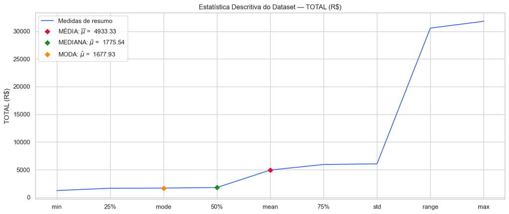

```
Estatística descritiva do dataset:
min       1231.71
25%       1648.20
mode      1677.93
50%       1775.54
mean      4933.33
75%       5935.58
std       6050.04
range    30570.88
max      31802.59
Name: TOTAL (R$), dtype: float64
```

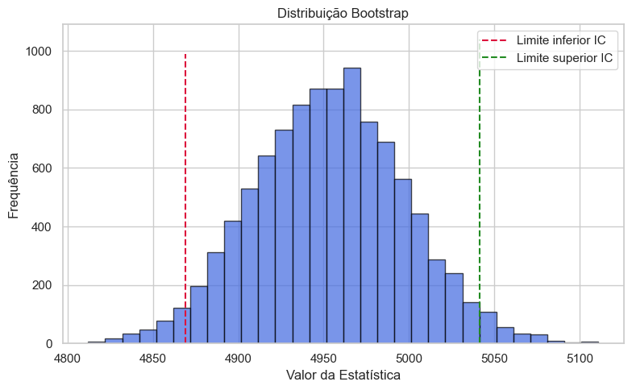

```
Intervalo de Confiança (95%):
LOW :  4869.02
HIGH:  5041.54
SE  :  44.02
```

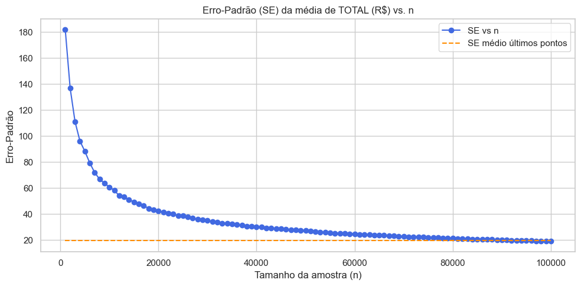

```
SE médio nas últimas janelas (estabilização aproximada): 19.5861
Sugestão automática de n* (achatamento do SE ~1%): 1000
       n  half_width  target_half_width  meets
0   1000  376.934264          246.66651  False
1   2000  266.005949          246.66651  False
2   4000  185.024877          246.66651   True
3   8000  127.710760          246.66651   True
4  12000  107.243477          246.66651   True
5  20000   85.378668          246.66651   True
6  40000   61.739172          246.66651   True
7  80000   42.801879          246.66651   True
n mínimo para ±5% da média (IC 95%): 4000
```

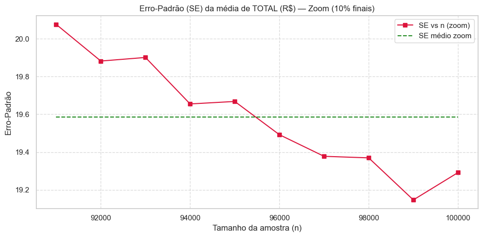

```
SE médio na região de zoom (últimos 10 pontos): 19.5861
```

```python
def AtividadeA1_1(x_series: pd.Series,
                  target_label: str = "TOTAL (R$)",
                  n_inicial: int = 1_000,
                  n_final: int = 100_000,
                  passo: int = 1_000,
                  rel_drop_threshold: float = 0.01,
                  window: int = 5,
                  n_piloto: int | None = None,
                  show_zoom_share: float = 0.10):
    """
    Atividade A1.1 — Tamanho da Amostra

    Essa função calcula o tamanho de amostra necessário para estimar a média
    de uma variável numérica de forma estável. A ideia é:
    - rodar estatística descritiva,
    - aplicar bootstrap para visualizar intervalo de confiança,
    - varrer tamanhos de amostra e calcular o erro-padrão (SE),
    - identificar onde o SE estabiliza,
    - verificar um critério de precisão relativa (±5% da média),
    - gerar gráficos gerais e de zoom.

    Parâmetros
    ----------
    x_series : pd.Series
        Série numérica da variável alvo já filtrada/limpa.
    target_label : str
        Nome da variável alvo para exibição nos gráficos.
    n_inicial : int
        Valor inicial da varredura de n.
    n_final : int
        Valor final da varredura de n.
    passo : int
        Incremento da varredura.
    rel_drop_threshold : float
        Limiar de queda relativa do SE para considerar estabilização.
    window : int
        Tamanho da janela da média móvel no cálculo de estabilização.
    n_piloto : int | None
        Amostra piloto usada no bootstrap inicial.
    show_zoom_share : float
        Percentual final da curva usado no gráfico de zoom.

    Retorna
    -------
    dict
        Contém n_star, tabela de precisão relativa, n_min_5pct,
        vetores ns e array_se, resultado do bootstrap piloto e N_POP.
    """
    # preparo da série (garantindo numérica e sem negativos)
    x_full = pd.to_numeric(pd.Series(x_series), errors="coerce").dropna().astype(float)
    x_full = x_full[x_full >= 0]
    N_POP = len(x_full)
    print(f"Tamanho disponível (pós-limpeza) para '{target_label}': {N_POP:,} observações.")

    # estatística descritiva
    PlotarStatistic(x_full, yLabel=target_label, title_suffix=f"— {target_label}")

    # bootstrap inicial em amostra piloto
    if n_piloto is None:
        n_piloto = 20_000 if N_POP >= 20_000 else max(1000, int(N_POP * 0.8))
    res_boot = Bootstrap_Distribution(
        x_full.sample(n=n_piloto, replace=False, random_state=42).values,
        metric=np.mean, bins=30, ci=0.95, seed=42
    )

    # curva SE vs n
    ns = list(range(n_inicial, min(n_final, N_POP) + 1, passo))
    array_se = np.zeros(len(ns), dtype=float)
    for j, n in enumerate(ns):
        tb = x_full.sample(n=n, replace=False, random_state=42 + j)
        array_se[j] = SE(tb)

    plt.figure(figsize=(10,5))
    plt.plot(ns, array_se, marker='o', color='royalblue', label="SE vs n")
    if len(array_se) >= 10:
        plt.hlines(np.mean(array_se[-10:]), ns[0], ns[-1],
                   linestyles='--', colors='darkorange',
                   label="SE médio últimos pontos")
    plt.title(f"Erro-Padrão (SE) da média de {target_label} vs. n")
    plt.ylabel('Erro-Padrão')
    plt.xlabel('Tamanho da amostra (n)')
    plt.legend()
    plt.tight_layout()
    plt.show()

    if len(array_se) >= 10:
        print(f"SE médio nas últimas janelas (estabilização aproximada): {np.mean(array_se[-10:]):.4f}")

    # sugestão de n* pelo achatamento do SE
    n_star = find_stabilization_n(ns, array_se, rel_drop_threshold=rel_drop_threshold, window=window)
    print(f"Sugestão automática de n* (achatamento do SE ~{int(rel_drop_threshold*100)}%): {n_star}")

    # critério de ±5% da média
    grid = [1_000, 2_000, 4_000, 8_000, 12_000, 20_000, 40_000, 80_000]
    table_ci, n_min_5 = pick_n_for_relative_margin(x_full.values, rel_margin=0.05, alpha=0.05, grid=grid)
    print(table_ci)
    print(f"n mínimo para ±5% da média (IC 95%): {n_min_5}")

    # gráfico de zoom nos últimos pontos
    zoom_len = max(1, int(len(ns) * show_zoom_share))
    ns_zoom  = ns[-zoom_len:]
    se_zoom  = array_se[-zoom_len:]

    plt.figure(figsize=(10,5))
    plt.plot(ns_zoom, se_zoom, marker='s', color='crimson', label="SE vs n (zoom)")
    plt.hlines(np.mean(se_zoom), ns_zoom[0], ns_zoom[-1],
               linestyles='--', colors='forestgreen',
               label="SE médio zoom")
    plt.title(f"Erro-Padrão (SE) da média de {target_label} — Zoom ({int(show_zoom_share*100)}% finais)")
    plt.ylabel('Erro-Padrão')
    plt.xlabel('Tamanho da amostra (n)')
    plt.grid(True, linestyle="--", alpha=0.7)
    plt.legend()
    plt.tight_layout()
    plt.show()

    print(f"SE médio na região de zoom (últimos {len(se_zoom)} pontos): {np.mean(se_zoom):.4f}")

    return {
        "n_star": n_star,
        "table_ci_5pct": table_ci,
        "n_min_5pct": n_min_5,
        "ns": ns,
        "array_se": array_se,
        "pilot_bootstrap": res_boot,
        "N_POP": N_POP
    }


resultados = AtividadeA1_1(
    x_series=df["TOTAL (R$)"],
    target_label="TOTAL (R$)",
    n_inicial=1_000, n_final=100_000, passo=1_000,
    rel_drop_threshold=0.01, window=5,
    n_piloto=None, show_zoom_share=0.10
)
```

### Atividade A1.2: Analisar os outliers

```python
def AtividadeA1_2(x_series: pd.Series, var_label: str = ""):
    """
    Atividade A1.2 — Analisar os Outliers

    Recebe uma série numérica e identifica outliers usando o método do IQR.
    Exibe boxplot, histograma e estatísticas resumidas.

    Parâmetros
    ----------
    x_series : pd.Series
        Série numérica da variável a ser analisada.
    var_label : str
        Nome da variável (usado nos títulos dos gráficos).

    Retorna
    -------
    dict
        Contém limites inferiores e superiores, contagem de outliers
        inferiores/superiores e proporção em relação ao total.
    """
    x = pd.to_numeric(x_series, errors="coerce").dropna().astype(float)

    Q1 = x.quantile(0.25)
    Q3 = x.quantile(0.75)
    IQR = Q3 - Q1
    lim_inf = Q1 - 1.5 * IQR
    lim_sup = Q3 + 1.5 * IQR

    outliers_inf = (x < lim_inf).sum()
    outliers_sup = (x > lim_sup).sum()
    total_outliers = outliers_inf + outliers_sup
    prop_outliers = total_outliers / len(x)

    fig, axes = plt.subplots(1, 2, figsize=(14, 5))
    sns.boxplot(x=x, ax=axes[0], color="royalblue")
    axes[0].set_title(f"Boxplot — {var_label}")

    sns.histplot(x, kde=True, ax=axes[1], color="crimson")
    axes[1].axvline(lim_inf, color="black", linestyle="--", label="Limite inferior")
    axes[1].axvline(lim_sup, color="black", linestyle="--", label="Limite superior")
    axes[1].legend()
    axes[1].set_title(f"Histograma — {var_label}")
    plt.tight_layout()
    plt.show()

    print(f"Variável: {var_label}")
    print(f"Q1 = {Q1:.2f} | Q3 = {Q3:.2f} | IQR = {IQR:.2f}")
    print(f"Limite inferior = {lim_inf:.2f} | Limite superior = {lim_sup:.2f}")
    print(f"Outliers abaixo: {outliers_inf}")
    print(f"Outliers acima : {outliers_sup}")
    print(f"Total de outliers: {total_outliers} ({prop_outliers:.2%} do total)")

    return {
        "Q1": Q1,
        "Q3": Q3,
        "IQR": IQR,
        "lim_inf": lim_inf,
        "lim_sup": lim_sup,
        "outliers_inf": outliers_inf,
        "outliers_sup": outliers_sup,
        "total_outliers": total_outliers,
        "prop_outliers": prop_outliers
    }
```

```
============================================================
Analisando outliers em: TOTAL (R$)
```

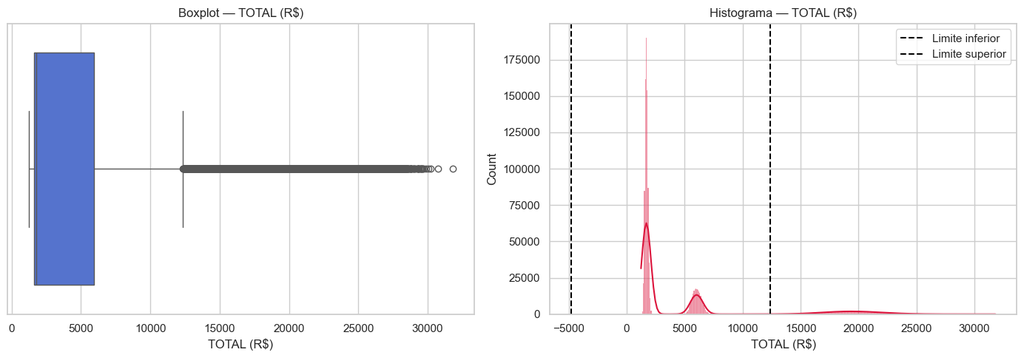

```
Variável: TOTAL (R$)
Q1 = 1648.20 | Q3 = 5935.58 | IQR = 4287.38
Limite inferior = -4782.87 | Limite superior = 12366.65
Outliers abaixo: 0
Outliers acima : 149745
Total de outliers: 149745 (13.37% do total)
============================================================
Analisando outliers em: RENDA BRUTO (R$)
```

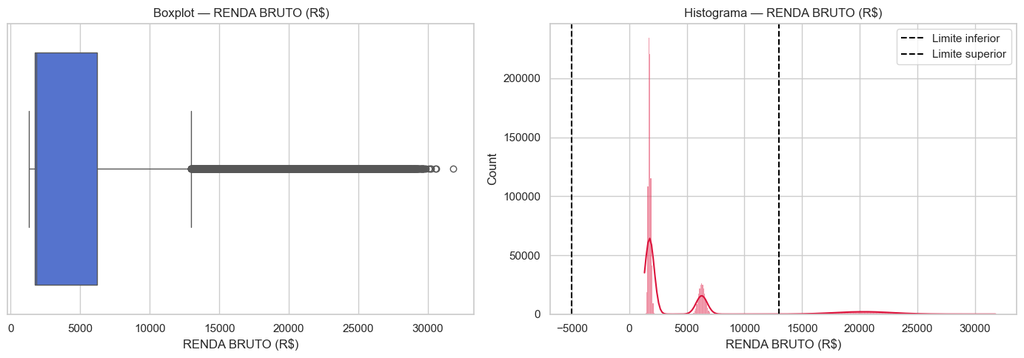

```
Variável: RENDA BRUTO (R$)
Q1 = 1724.84 | Q3 = 6220.81 | IQR = 4495.97
Limite inferior = -5019.11 | Limite superior = 12964.76
Outliers abaixo: 0
Outliers acima : 149795
Total de outliers: 149795 (13.37% do total)
============================================================
Analisando outliers em: alcohol
```

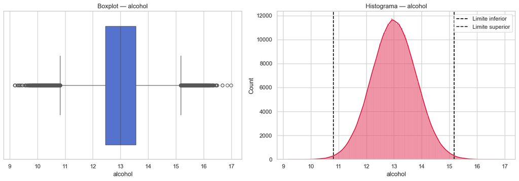

```
Variável: alcohol
Q1 = 12.46 | Q3 = 13.55 | IQR = 1.09
Limite inferior = 10.82 | Limite superior = 15.18
Outliers abaixo: 4022
Outliers acima : 3922
Total de outliers: 7944 (0.71% do total)
============================================================
Analisando outliers em: flavanoids
```

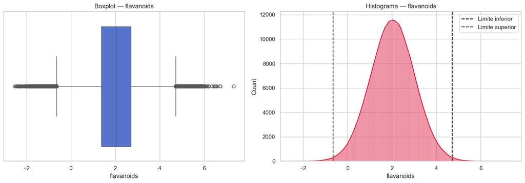

```
Variável: flavanoids
Q1 = 1.36 | Q3 = 2.70 | IQR = 1.34
Limite inferior = -0.65 | Limite superior = 4.71
Outliers abaixo: 3907
Outliers acima : 3918
Total de outliers: 7825 (0.70% do total)
============================================================
Analisando outliers em: color_intensity
```

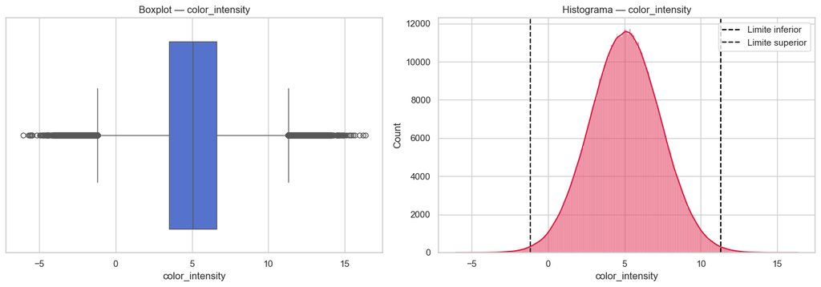

```
Variável: color_intensity
Q1 = 3.50 | Q3 = 6.62 | IQR = 3.12
Limite inferior = -1.17 | Limite superior = 11.29
Outliers abaixo: 3920
Outliers acima : 3912
Total de outliers: 7832 (0.70% do total)
============================================================
Analisando outliers em: proline
```

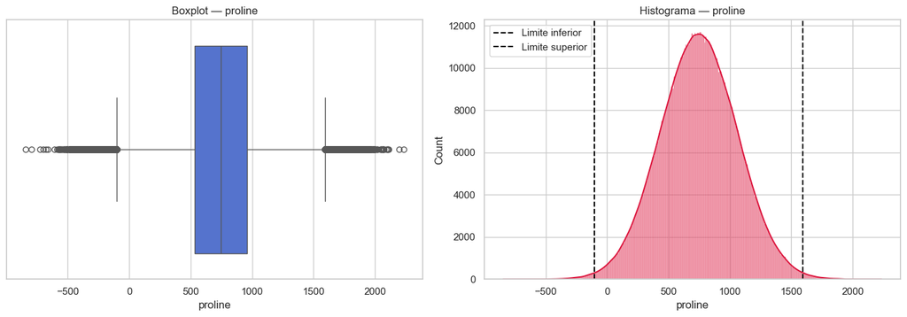

```
Variável: proline
Q1 = 535.23 | Q3 = 958.91 | IQR = 423.69
Limite inferior = -100.30 | Limite superior = 1594.44
Outliers abaixo: 3997
Outliers acima : 3863
Total de outliers: 7860 (0.70% do total)
```

```python
# lista de variáveis obrigatórias e relevantes
vars_outliers = [
    "TOTAL (R$)",
    "RENDA BRUTO (R$)",
    "alcohol",
    "flavanoids",
    "color_intensity",
    "proline"
]

# dicionário para salvar os resultados
resultados_outliers = {}

# execução para cada variável
for col in vars_outliers:
    print("="*60)
    print(f"Analisando outliers em: {col}")
    resultados_outliers[col] = AtividadeA1_2(df[col], var_label=col)
```

#### Removendo outliers das colunas numéricas

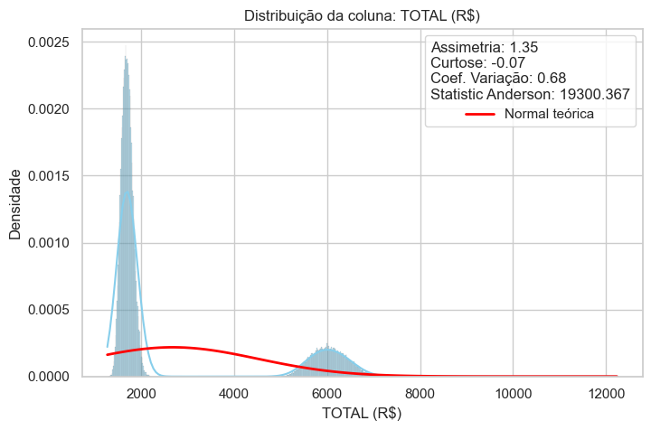

```python
n = 95500
target = 'TOTAL (R$)'
df, _ = remover_outliers_df(df)
# Return a random sample of items from an axis of object.
sample_df = df.sample(n=n, replace=False)


sample_df_2 = df.sample(n=n, replace=False)


analisar_distribuicao(sample_df, target)
```

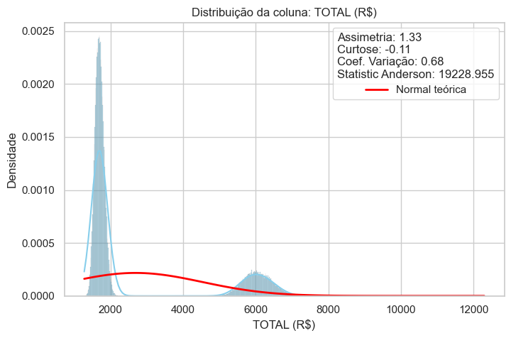

```python
analisar_distribuicao(sample_df_2, target)
```

### Atividade A1.3: Testes de Hipóteses ([Link](https://colab.research.google.com/drive/1_YGamH-qOWSNaCKG5kVlLiZPuXv5lT34?usp=sharing))

#### A1.3.1: Teste de Normalidade

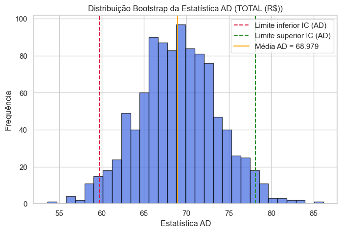

```
=== Teste de Normalidade (Anderson-Darling) com Bootstrap ===
Tamanho médio pós-outlier por iteração: 73,055
Média da Estatística AD (bootstrap): 68.9789
Erro-Padrão (SE AD): 4.7298
IC AD (95%): [59.7324, 78.1043]
Proporção de rejeição H0: 100.00%
Erro-Padrão (SE %): 0.00%
IC Proporção (%): [100.0%, 100.0%]
Assimetria: 0.2744 | Curtose: -0.0542 | Coef. Variação: 0.0733
```

```python
import numpy as np
import pandas as pd
import matplotlib.pyplot as plt
from scipy.stats import anderson, skew, kurtosis

def normalidade_A1_3_1(
    df: pd.DataFrame,
    col: str = "TOTAL (R$)",
    n_boot: int = 95_500,   # tamanho da subamostra por iteração
    B: int = 1000,
    alpha: float = 0.05,
    seed: int = 42,
    bins: int = 30
):
    """
    Atividade A1.3.1 — Teste de Normalidade (Anderson-Darling) com Bootstrap.

    A cada iteração do bootstrap:
      1) sorteia n_boot linhas de df com reposição (duas amostras independentes),
      2) remove outliers em cada amostra via remover_outliers_df(),
      3) calcula a estatística AD na coluna `col` da primeira amostra,
      4) registra se rejeitou ou não H0 (normalidade).

    Além das estatísticas da distribuição AD, calcula também a
    proporção de rejeição (%) e seu intervalo de confiança.
    """
    rng = np.random.default_rng(seed)
    stats_boot = []
    decisions = []  # 1=rejeita H0, 0=não rejeita
    Ns = []

    N_total = len(df)
    n_boot_eff = min(n_boot, N_total)

    for _ in range(B):
        # 1) sorteios independentes
        idx1 = rng.integers(0, N_total, size=n_boot_eff)
        df_boot_1 = df.iloc[idx1]

        # 2) remover outliers
        sample_1, _ = remover_outliers_df(df_boot_1)

        # 3) coluna alvo
        x = pd.to_numeric(sample_1[col], errors="coerce").dropna().astype(float).values
        if x.size >= 5:
            ad_stat, crit_vals, _ = anderson(x)
            stats_boot.append(ad_stat)
            Ns.append(x.size)

            # 4) decisão H0 normalidade (nível 5%)
            reject = 1 if ad_stat > crit_vals[2] else 0
            decisions.append(reject)

    stats_boot = np.asarray(stats_boot, dtype=float)
    decisions = np.asarray(decisions, dtype=int)

    if stats_boot.size == 0:
        raise ValueError("Nenhuma iteração válida: após remover outliers, não houve dados suficientes.")

    # Estatísticas AD
    ad_mean = stats_boot.mean()
    se_ad = stats_boot.std(ddof=1)
    ci_low_ad = np.percentile(stats_boot, 100 * (alpha / 2))
    ci_high_ad = np.percentile(stats_boot, 100 * (1 - alpha / 2))

    # Proporção de rejeição
    p_hat = decisions.mean()
    se_prop = decisions.std(ddof=1)
    ci_low_prop = np.percentile(decisions, 100 * (alpha / 2))
    ci_high_prop = np.percentile(decisions, 100 * (1 - alpha / 2))

    # Tamanho médio da amostra
    N_mean = int(np.round(np.mean(Ns))) if Ns else 0

    # Métricas descritivas da última amostra
    x_final = pd.to_numeric(sample_1[col], errors="coerce").dropna().astype(float).values
    skewness = skew(x_final) if x_final.size > 2 else np.nan
    kurt_val = kurtosis(x_final) if x_final.size > 3 else np.nan
    coef_var = (x_final.std(ddof=1) / x_final.mean()) if x_final.size > 1 and x_final.mean() != 0 else np.nan

    # Plot da distribuição bootstrap (estatística AD)
    fig, ax = plt.subplots(figsize=(8, 5))
    ax.hist(stats_boot, bins=bins, color="royalblue", edgecolor="black", alpha=0.7)
    ax.axvline(ci_low_ad, color="crimson", linestyle="--", label="Limite inferior IC (AD)")
    ax.axvline(ci_high_ad, color="forestgreen", linestyle="--", label="Limite superior IC (AD)")
    ax.axvline(ad_mean, color="orange", linestyle="-", label=f"Média AD = {ad_mean:.3f}")
    ax.set_title(f"Distribuição Bootstrap da Estatística AD ({col})")
    ax.set_xlabel("Estatística AD")
    ax.set_ylabel("Frequência")
    ax.legend()
    plt.show()

    # Prints
    print("=== Teste de Normalidade (Anderson-Darling) com Bootstrap ===")
    print(f"Tamanho médio pós-outlier por iteração: {N_mean:,}")
    print(f"Média da Estatística AD (bootstrap): {ad_mean:.4f}")
    print(f"Erro-Padrão (SE AD): {se_ad:.4f}")
    print(f"IC AD ({int((1-alpha)*100)}%): [{ci_low_ad:.4f}, {ci_high_ad:.4f}]")
    print(f"Proporção de rejeição H0: {p_hat*100:.2f}%")
    print(f"Erro-Padrão (SE %): {se_prop*100:.2f}%")
    print(f"IC Proporção (%): [{ci_low_prop*100:.1f}%, {ci_high_prop*100:.1f}%]")
    print(f"Assimetria: {skewness:.4f} | Curtose: {kurt_val:.4f} | Coef. Variação: {coef_var:.4f}")

    return {
        "AD_mean": ad_mean,
        "AD_SE": se_ad,
        "AD_CI_low": ci_low_ad,
        "AD_CI_high": ci_high_ad,
        "Reject_prop": p_hat,
        "Reject_SE": se_prop,
        "Reject_CI_low": ci_low_prop,
        "Reject_CI_high": ci_high_prop,
        "Skewness": skewness,
        "Kurtosis": kurt_val,
        "CoefVar": coef_var,
        "N_mean": N_mean
    }


# Exemplo de execução
resultados_normalidade = normalidade_A1_3_1(
    df,
    col="TOTAL (R$)",
    n_boot=95000,
    B=1000,
    alpha=0.05,
    seed=42,
    bins=30
)
```

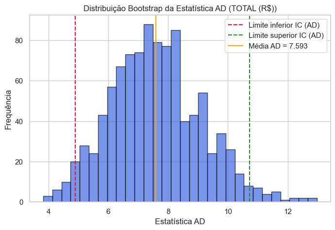

```
=== Teste de Normalidade (Anderson-Darling) com Bootstrap ===
Tamanho médio pós-outlier por iteração: 7,678
Média da Estatística AD (bootstrap): 7.5927
Erro-Padrão (SE AD): 1.5151
IC AD (95%): [4.8916, 10.7224]
Proporção de rejeição H0: 100.00%
Erro-Padrão (SE %): 0.00%
IC Proporção (%): [100.0%, 100.0%]
Assimetria: 0.2576 | Curtose: 0.0191 | Coef. Variação: 0.0741
```

```python
# Exemplo de execução
resultados_normalidade = normalidade_A1_3_1(
    df,
    col="TOTAL (R$)",
    n_boot=10000,
    B=1000,
    alpha=0.05,
    seed=42,
    bins=30
)
```

#### A1.3.2: Teste de Independência

Como essa variável não é normal, aplica-se somente os testes não paramétricos nos demais testes de hipótese.

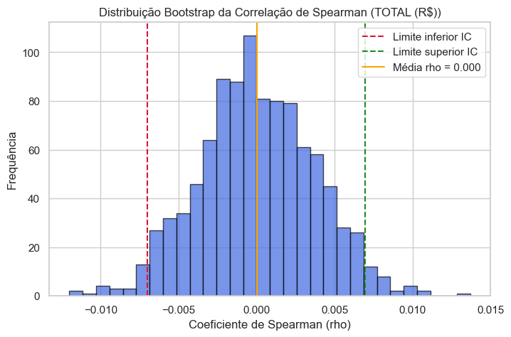

```
=== Teste de Independência (Spearman) com Bootstrap ===
Tamanho médio das amostras pós-outlier: 73,358
Média rho (bootstrap): 0.0000
Erro-Padrão (SE): 0.0037
Intervalo de Confiança (95%): [-0.0070, 0.0070]
Resultado: ✅ Não rejeita H0 (as amostras podem ser independentes).
```

```python
from scipy.stats import spearmanr

def independencia_A1_3_2(
    df: pd.DataFrame,
    col: str = "TOTAL (R$)",
    n_boot: int = 95_500,
    B: int = 1000,
    alpha: float = 0.05,
    seed: int = 42,
    bins: int = 30
):
    """
    Atividade A1.3.2 — Teste de Independência (Spearman) com Bootstrap.

    Em cada iteração do bootstrap:
      1) sorteia n_boot linhas de df para formar df_boot_1 e df_boot_2,
      2) remove outliers em cada subamostra (remover_outliers_df),
      3) calcula a correlação de Spearman entre sample_1[col] e sample_2[col].

    Parâmetros
    ----------
    df : pd.DataFrame
        DataFrame original.
    col : str, default="TOTAL (R$)"
        Nome da coluna numérica alvo.
    n_boot : int, default=95_500
        Tamanho da subamostra em cada iteração.
    B : int, default=1000
        Número de reamostragens bootstrap.
    alpha : float, default=0.05
        Nível de significância para IC.
    seed : int, default=42
        Semente para reprodutibilidade.
    bins : int, default=30
        Número de bins no histograma.

    Retorna
    -------
    dict
        Contendo:
        - 'rho_mean'   : média do coeficiente rho (bootstrap)
        - 'rho_SE'     : erro-padrão
        - 'rho_CI_low' : limite inferior IC
        - 'rho_CI_high': limite superior IC
        - 'N_mean'     : tamanho médio pós-outlier
    """
    rng = np.random.default_rng(seed)
    stats_boot = []
    Ns = []

    N_total = len(df)
    n_boot_eff = min(n_boot, N_total)

    for _ in range(B):
        # sorteios independentes
        idx1 = rng.integers(0, N_total, size=n_boot_eff)
        idx2 = rng.integers(0, N_total, size=n_boot_eff)
        df_boot_1 = df.iloc[idx1]
        df_boot_2 = df.iloc[idx2]

        # remover outliers
        sample_1, _ = remover_outliers_df(df_boot_1)
        sample_2, _ = remover_outliers_df(df_boot_2)

        x = pd.to_numeric(sample_1[col], errors="coerce").dropna().astype(float).values
        y = pd.to_numeric(sample_2[col], errors="coerce").dropna().astype(float).values
        n = min(len(x), len(y))

        if n >= 5:
            rho, _ = spearmanr(x[:n], y[:n])  # truncar ao mesmo tamanho
            stats_boot.append(rho)
            Ns.append(n)

    stats_boot = np.array(stats_boot)
    rho_mean = stats_boot.mean()
    se = stats_boot.std(ddof=1)
    ci_low = np.percentile(stats_boot, 100 * (alpha / 2))
    ci_high = np.percentile(stats_boot, 100 * (1 - alpha / 2))
    N_mean = int(np.round(np.mean(Ns))) if Ns else 0

    # Plot
    fig, ax = plt.subplots(figsize=(8, 5))
    ax.hist(stats_boot, bins=bins, color="royalblue", edgecolor="black", alpha=0.7)
    ax.axvline(ci_low, color="crimson", linestyle="--", label="Limite inferior IC")
    ax.axvline(ci_high, color="forestgreen", linestyle="--", label="Limite superior IC")
    ax.axvline(rho_mean, color="orange", linestyle="-", label=f"Média rho = {rho_mean:.3f}")
    ax.set_title(f"Distribuição Bootstrap da Correlação de Spearman ({col})")
    ax.set_xlabel("Coeficiente de Spearman (rho)")
    ax.set_ylabel("Frequência")
    ax.legend()
    plt.show()

    # Print
    print("=== Teste de Independência (Spearman) com Bootstrap ===")
    print(f"Tamanho médio das amostras pós-outlier: {N_mean:,}")
    print(f"Média rho (bootstrap): {rho_mean:.4f}")
    print(f"Erro-Padrão (SE): {se:.4f}")
    print(f"Intervalo de Confiança ({int((1-alpha)*100)}%): [{ci_low:.4f}, {ci_high:.4f}]")

    if ci_low <= 0 <= ci_high:
        print("Resultado: ✅ Não rejeita H0 (as amostras podem ser independentes).")
    else:
        print("Resultado: ❌ Rejeita H0 (existe dependência entre as amostras).")

    return {
        "rho_mean": rho_mean,
        "rho_SE": se,
        "rho_CI_low": ci_low,
        "rho_CI_high": ci_high,
        "N_mean": N_mean
    }
resultados_indep = independencia_A1_3_2(
    df,
    col="TOTAL (R$)",
    n_boot=95_500,  # tamanho da subamostra
    B=1000,
    alpha=0.05,
    seed=42
)
```

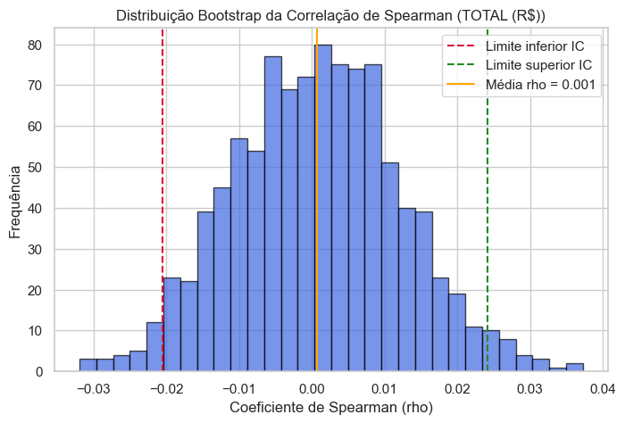

```
=== Teste de Independência (Spearman) com Bootstrap ===
Tamanho médio das amostras pós-outlier: 7,650
Média rho (bootstrap): 0.0007
Erro-Padrão (SE): 0.0114
Intervalo de Confiança (95%): [-0.0205, 0.0242]
Resultado: ✅ Não rejeita H0 (as amostras podem ser independentes).
```

```python
resultados_indep = independencia_A1_3_2(
    df,
    col="TOTAL (R$)",
    n_boot=10000,  # tamanho da subamostra
    B=1000,
    alpha=0.05,
    seed=42
)
```

#### A1.3.3: Teste de Distribuição

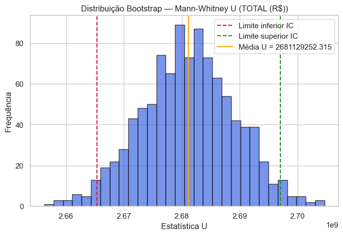

```
=== Teste de Distribuição (Mann-Whitney U) com Bootstrap ===
Tamanhos pós-outlier: N1 = 73,391 | N2 = 73,305
Média da estatística U (bootstrap): 2681129252.32
Erro-Padrão (SE): 8079374.67
IC (95%): [2665359133.05, 2697010027.40]
Estatística U original: 2680938494.00 | p-valor: 2.6576e-01
Resultado: ✅ Não rejeita H0 (as amostras podem vir da mesma distribuição).
```

```python
from scipy.stats import mannwhitneyu


def distribuicao_A1_3_3(
    df: pd.DataFrame,
    col: str = "TOTAL (R$)",
    n_boot: int = 95_500,
    B: int = 1000,
    alpha: float = 0.05,
    seed: int = 42,
    bins: int = 30
):
    """
    Atividade A1.3.3 — Teste de Distribuição (Mann-Whitney U) com Bootstrap.

    Passos:
      1) Sorteia duas amostras fixas de tamanho n_boot.
      2) Remove outliers em cada subamostra.
      3) Calcula o Mann-Whitney U "original" nessas duas amostras.
      4) Faz bootstrap reamostrando internamente essas amostras
         para estimar a distribuição de U.
    """
    rng = np.random.default_rng(seed)

    # Amostras fixas
    idx1 = rng.integers(0, len(df), size=n_boot)
    idx2 = rng.integers(0, len(df), size=n_boot)
    df_boot_1 = df.iloc[idx1]
    df_boot_2 = df.iloc[idx2]

    sample_1, _ = remover_outliers_df(df_boot_1)
    sample_2, _ = remover_outliers_df(df_boot_2)

    x_full = pd.to_numeric(sample_1[col], errors="coerce").dropna().astype(float).values
    y_full = pd.to_numeric(sample_2[col], errors="coerce").dropna().astype(float).values

    # U original
    u_orig, p_value = mannwhitneyu(x_full, y_full, alternative="two-sided")

    # Bootstrap
    stats_boot, Ns1, Ns2 = [], [], []
    for _ in range(B):
        xb = rng.choice(x_full, size=len(x_full), replace=True)
        yb = rng.choice(y_full, size=len(y_full), replace=True)
        u_stat, _ = mannwhitneyu(xb, yb, alternative="two-sided")
        stats_boot.append(u_stat)
        Ns1.append(len(xb))
        Ns2.append(len(yb))

    stats_boot = np.array(stats_boot)
    u_mean = stats_boot.mean()
    se = stats_boot.std(ddof=1)
    ci_low = np.percentile(stats_boot, 100 * (alpha/2))
    ci_high = np.percentile(stats_boot, 100 * (1-alpha/2))

    # Plot
    fig, ax = plt.subplots(figsize=(8,5))
    ax.hist(stats_boot, bins=bins, color="royalblue", edgecolor="black", alpha=0.7)
    ax.axvline(ci_low, color="crimson", linestyle="--", label="Limite inferior IC")
    ax.axvline(ci_high, color="forestgreen", linestyle="--", label="Limite superior IC")
    ax.axvline(u_mean, color="orange", linestyle="-", label=f"Média U = {u_mean:.3f}")
    ax.set_title(f"Distribuição Bootstrap — Mann-Whitney U ({col})")
    ax.set_xlabel("Estatística U")
    ax.set_ylabel("Frequência")
    ax.legend()
    plt.show()

    # Print
    print("=== Teste de Distribuição (Mann-Whitney U) com Bootstrap ===")
    print(f"Tamanhos pós-outlier: N1 = {len(x_full):,} | N2 = {len(y_full):,}")
    print(f"Média da estatística U (bootstrap): {u_mean:.2f}")
    print(f"Erro-Padrão (SE): {se:.2f}")
    print(f"IC ({int((1-alpha)*100)}%): [{ci_low:.2f}, {ci_high:.2f}]")
    print(f"Estatística U original: {u_orig:.2f} | p-valor: {p_value:.4e}")

    if p_value < alpha:
        print("Resultado: ❌ Rejeita H0 (as amostras NÃO têm a mesma distribuição).")
    else:
        print("Resultado: ✅ Não rejeita H0 (as amostras podem vir da mesma distribuição).")

    return {
        "U_mean": u_mean,
        "U_SE": se,
        "U_CI_low": ci_low,
        "U_CI_high": ci_high,
        "U_original": u_orig,
        "p_value": p_value,
        "N1": len(x_full),
        "N2": len(y_full)
    }

resultados_dist = distribuicao_A1_3_3(
    df,
    col="TOTAL (R$)",
    n_boot=95_500,
    B=1000,
    alpha=0.05,
    seed=42
)
```

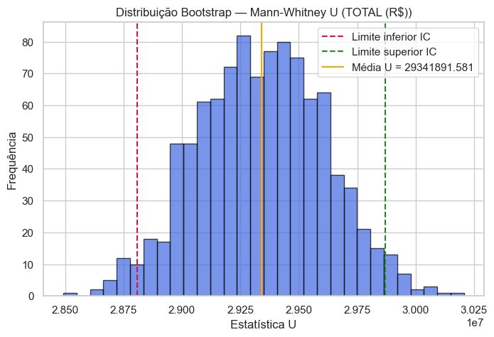

```
=== Teste de Distribuição (Mann-Whitney U) com Bootstrap ===
Tamanhos pós-outlier: N1 = 7,668 | N2 = 7,636
Média da estatística U (bootstrap): 29341891.58
Erro-Padrão (SE): 270644.65
IC (95%): [28808656.18, 29868915.89]
Estatística U original: 29339980.00 | p-valor: 8.1610e-01
Resultado: ✅ Não rejeita H0 (as amostras podem vir da mesma distribuição).
```

```python
resultados_dist = distribuicao_A1_3_3(
    df,
    col="TOTAL (R$)",
    n_boot=10000,
    B=1000,
    alpha=0.05,
    seed=42
)
```

#### A1.3.4: Teste das Médias Amostrais

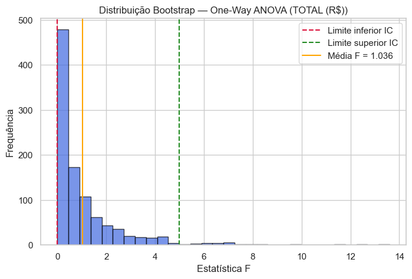

```
=== Teste de Médias (ANOVA) com Bootstrap ===
Tamanhos médios pós-outlier: N1 = 73439 | N2 = 73437
Média da estatística F (bootstrap): 1.036
Erro-Padrão (SE): 1.506
Intervalo de Confiança (95%): [0.001, 4.989]
Estatística F original: 0.000 | p-valor: 1.0000e+00
Resultado: ✅ Não rejeita H0 (as médias podem ser iguais).
```

```python
from scipy.stats import f_oneway

def medias_A1_3_4(
    df: pd.DataFrame,
    col: str = "TOTAL (R$)",
    n_boot: int = 95_500,
    B: int = 1000,
    alpha: float = 0.05,
    seed: int = 42,
    bins: int = 30
):
    """
    Atividade A1.3.4 — Teste das Médias Amostrais (One-Way ANOVA) com Bootstrap.

    Em cada iteração do bootstrap:
      1) sorteia n_boot linhas de df para formar df_boot_1 e df_boot_2,
      2) remove outliers em cada subamostra (remover_outliers_df),
      3) aplica o teste One-Way ANOVA (f_oneway).

    Parâmetros
    ----------
    df : pd.DataFrame
        DataFrame original.
    col : str, default="TOTAL (R$)"
        Nome da coluna numérica alvo.
    n_boot : int, default=95_500
        Tamanho da subamostra em cada iteração.
    B : int, default=1000
        Número de reamostragens bootstrap.
    alpha : float, default=0.05
        Nível de significância para IC.
    seed : int, default=42
        Semente para reprodutibilidade.
    bins : int, default=30
        Número de bins no histograma.

    Retorna
    -------
    dict
        Contendo:
        - 'F_mean'    : média da estatística F (bootstrap)
        - 'F_SE'      : erro-padrão
        - 'F_CI_low'  : limite inferior IC
        - 'F_CI_high' : limite superior IC
        - 'F_original': estatística F do teste original
        - 'p_value'   : p-valor do teste original
        - 'N1', 'N2'  : tamanhos médios pós-outlier
    """
    rng = np.random.default_rng(seed)
    stats_boot = []
    Ns1, Ns2 = [], []

    N_total = len(df)
    n_boot_eff = min(n_boot, N_total)

    for _ in range(B):
        # sorteios independentes
        idx1 = rng.integers(0, N_total, size=n_boot_eff)
        idx2 = rng.integers(0, N_total, size=n_boot_eff)
        df_boot_1 = df.iloc[idx1]
        df_boot_2 = df.iloc[idx2]

        # remover outliers
        sample_1, _ = remover_outliers_df(df_boot_1)
        sample_2, _ = remover_outliers_df(df_boot_2)

        x = pd.to_numeric(sample_1[col], errors="coerce").dropna().astype(float).values
        y = pd.to_numeric(sample_2[col], errors="coerce").dropna().astype(float).values

        if len(x) >= 5 and len(y) >= 5:
            f_stat, _ = f_oneway(x, y)
            stats_boot.append(f_stat)
            Ns1.append(len(x))
            Ns2.append(len(y))

    stats_boot = np.array(stats_boot)
    f_mean = stats_boot.mean()
    se = stats_boot.std(ddof=1)
    ci_low = np.percentile(stats_boot, 100 * (alpha / 2))
    ci_high = np.percentile(stats_boot, 100 * (1 - alpha / 2))

    # Teste original com df completo (pós-outlier)
    sample_1, _ = remover_outliers_df(df)
    sample_2, _ = remover_outliers_df(df)
    x_full = pd.to_numeric(sample_1[col], errors="coerce").dropna().astype(float).values
    y_full = pd.to_numeric(sample_2[col], errors="coerce").dropna().astype(float).values
    f_orig, p_value = f_oneway(x_full, y_full)

    # Plot
    fig, ax = plt.subplots(figsize=(8, 5))
    ax.hist(stats_boot, bins=bins, color="royalblue", edgecolor="black", alpha=0.7)
    ax.axvline(ci_low, color="crimson", linestyle="--", label="Limite inferior IC")
    ax.axvline(ci_high, color="forestgreen", linestyle="--", label="Limite superior IC")
    ax.axvline(f_mean, color="orange", linestyle="-", label=f"Média F = {f_mean:.3f}")
    ax.set_title(f"Distribuição Bootstrap — One-Way ANOVA ({col})")
    ax.set_xlabel("Estatística F")
    ax.set_ylabel("Frequência")
    ax.legend()
    plt.show()

    # Print
    print("=== Teste de Médias (ANOVA) com Bootstrap ===")
    print(f"Tamanhos médios pós-outlier: N1 = {np.mean(Ns1):.0f} | N2 = {np.mean(Ns2):.0f}")
    print(f"Média da estatística F (bootstrap): {f_mean:.3f}")
    print(f"Erro-Padrão (SE): {se:.3f}")
    print(f"Intervalo de Confiança ({int((1-alpha)*100)}%): [{ci_low:.3f}, {ci_high:.3f}]")
    print(f"Estatística F original: {f_orig:.3f} | p-valor: {p_value:.4e}")

    if p_value < alpha:
        print("Resultado: ❌ Rejeita H0 (as médias são diferentes).")
    else:
        print("Resultado: ✅ Não rejeita H0 (as médias podem ser iguais).")

    return {
        "F_mean": f_mean,
        "F_SE": se,
        "F_CI_low": ci_low,
        "F_CI_high": ci_high,
        "F_original": f_orig,
        "p_value": p_value,
        "N1": int(np.mean(Ns1)) if Ns1 else 0,
        "N2": int(np.mean(Ns2)) if Ns2 else 0
    }
resultados_medias = medias_A1_3_4(
    df,
    col="TOTAL (R$)",
    n_boot=95_500,
    B=1000,
    alpha=0.05,
    seed=42
)
```

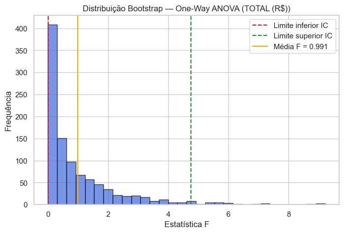

```
=== Teste de Médias (ANOVA) com Bootstrap ===
Tamanhos médios pós-outlier: N1 = 7676 | N2 = 7677
Média da estatística F (bootstrap): 0.991
Erro-Padrão (SE): 1.335
Intervalo de Confiança (95%): [0.002, 4.757]
Estatística F original: 0.000 | p-valor: 1.0000e+00
Resultado: ✅ Não rejeita H0 (as médias podem ser iguais).
```

```python
resultados_medias = medias_A1_3_4(
    df,
    col="TOTAL (R$)",
    n_boot=10000,
    B=1000,
    alpha=0.05,
    seed=42
)
```